# Milestone Report

Hiroo Ishikawa

2019/9/18

### Introduction

The objects of this course is; 1. Analyze a corpus of text documents to discover the structure in the data and how words are put together 2. Build and sampling from a predictive text model 3. Build a predictive text product

### Overview of this Reort

1. Read the texts from the Internet blogs, news and twitter.
2. Separate from the each text into words.
3. Exploratory analysis to build basic n-gram model, that is predicting the next word based on the previous 1, 2, or 3 words.
4. build basic n-gram model of Data sets

### 1. Read Data sets

For this analysis, the data texts are from blogs, news and twitter. The Selected language is English. Use following three fiiles.

- en_US.blogs.txt
- en_US.news.txt
- en_US.twitter.txt

As test, read a few lines of each data set.

```r
library(tidyverse)
```

```r
read_lines('en_US.blogs.txt',   skip=0, n_max=2L)
```

```
## [1] "In the years thereafter, most of the Oil fields and platforms were named after pagan “gods”."
## [2] "We love you Mr. Brown."
```

```r
read_lines('en_US.news.txt',    skip=0, n_max=2L)
```

```
## [1] "He wasn't home alone, apparently."
## [2] "The St. Louis plant had to close. It would die of old age. Workers had been making cars there since the onset of mass automotive production in the 1920s."
```

```r
read_lines('en_US.twitter.txt', skip=0, n_max=2L)
```

```
## [1] "How are you? Btw thanks for the RT. You gonna be in DC anytime soon? Love to see you. Been way, way too long."
## [2] "When you meet someone special... you'll know. Your heart will beat more rapidly and you'll smile for no reason."
```

In the files, there are some sentense in a line and lines of words separated by space.

### 2. Separate into words.

Read whole of the files.

```r
blog <- read_lines('en_US.blogs.txt',   skip=0)
news <- read_lines('en_US.news.txt',    skip=0)
twtr <- read_lines('en_US.twitter.txt', skip=0)
```

check out summary statistics of the dataset.

Number of lines;

```r
blog %>% length()
```

```
## [1] 899288
```

```r
news %>% length()
```

```
## [1] 1010242
```

```r
twtr %>% length()
```

```
## [1] 2360148
```

Length of each lines;

```r
line_len <- blog %>% str_length() %>% tibble(src='blogs',  length=.)
line_len <- news %>% str_length() %>% tibble(src='news',   length=.) %>% bind_rows(line_len, .)
line_len <- twtr %>% str_length() %>% tibble(src='twitter',length=.) %>% bind_rows(line_len, .)
line_len %>% group_by(src) %>% summarise(mean=round(mean(length),1),max=max(length))
```

```
## # A tibble: 3 x 3
##   src      mean   max
##   <chr>   <dbl> <int>
## 1 blogs   230   40833
## 2 news    201.  11384
## 3 twitter  68.7   140
```

Number of each lines;

```r
words <- blog %>% str_split(' ') %>% map_int(length) %>% tibble(src='blogs'  ,words=.)
words <- news %>% str_split(' ') %>% map_int(length) %>% tibble(src='news'   ,words=.) %>% bind_rows(words, .)
words <- twtr %>% str_split(' ') %>% map_int(length) %>% tibble(src='twitter',words=.) %>% bind_rows(words, .)
words %>% group_by(src) %>% summarise(mean=round(mean(words),1), max=max(words))
```

```
## # A tibble: 3 x 3
##   src      mean   max
##   <chr>   <dbl> <int>
## 1 blogs    41.5  6630
## 2 news     34    1792
## 3 twitter  12.9    47
```

Draw histograms length of each texts and Number of words.

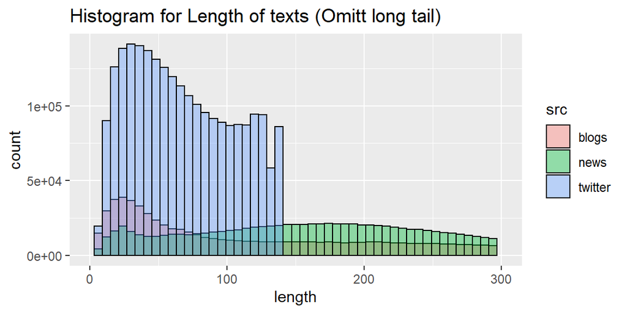

```r
ggplot(line_len,aes(x=length,fill=src))+ggtitle('Histogram for Length of texts (Omitt long tail)')+
    geom_histogram(position='identity',binwidth=6,color='black',alpha=0.4)+xlim(c(0,300))
```

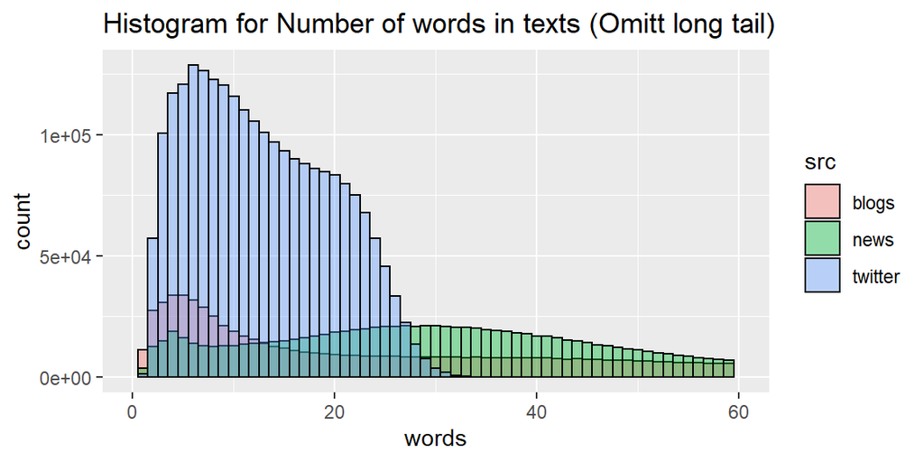

```r
ggplot(words,aes(x=words,fill=src))+ggtitle('Histogram for Number of words in texts (Omitt long tail)')+
    geom_histogram(position='identity',binwidth=1,color='black',alpha=0.4)+xlim(c(0,60))
```

### 3. Exploratory analysis to Build n-gram

#### Exploratory Points

1. Indicate End of Sentence - The last word don’t have following word.
2. Get next Word - use function lead()
3. filter the word to The first letter is alfabet - Other than alphabet are have no sence.
4. n-gram top N pattern - Leave the top N and throw away others, to model to make the model smaller, and too Many candidates are ineffective.

First, Use a part of data set to repeat trying in short turn around.

#### 1 Word n-gram

```r
x <- blog %>% sample(10000)

# W1: n-gram word, NW: Next word of n-gram, N: Number of occurrences
n1gram <- str_c(x, ' [[EOS]]' ) %>% str_split(' ') %>% unlist()%>%
    tibble(W1=.) %>% filter(str_detect(str_sub(W1,1,1),'[a-zA-Z]')) %>%
    mutate(NW=lead(W1)) %>% filter(W1!='[[EOS]]'&NW!='[[EOS]]') %>%
    arrange(W1,NW) %>% group_by(W1,NW) %>% summarize(N=n()) %>% filter(N>1) %>%
    group_by(W1) %>% top_n(3,N) %>% ungroup()

n1gram %>% head()
```

```
## # A tibble: 6 x 3
##   W1    NW         N
##   <chr> <chr>  <int>
## 1 a     few      253
## 2 a     little   244
## 3 a     lot      198
## 4 A     few       22
## 5 A     great      5
## 6 A     little    13
```

```r
n1gram %>% tail()
```

```
## # A tibble: 6 x 3
##   W1        NW            N
##   <chr>     <chr>     <int>
## 1 yourself. I             2
## 2 yourself. The           3
## 3 Youth     League        2
## 4 Yuck!     I             2
## 5 Z         Challenge     2
## 6 zoo       moorings,     2
```

Test the model

Input: ‘I’

```r
n1gram %>% filter(W1=='I') %>% arrange(desc(N))
```

```
## # A tibble: 3 x 3
##   W1    NW        N
##   <chr> <chr> <int>
## 1 I     have    512
## 2 I     was     488
## 3 I     am      422
```

Input: ‘was’

```r
n1gram %>% filter(W1=='was') %>% arrange(desc(N))
```

```
## # A tibble: 3 x 3
##   W1    NW        N
##   <chr> <chr> <int>
## 1 was   a       279
## 2 was   the     140
## 3 was   not      59
```

It’s looks like done well.

#### 2 Word n-gram

```r
# W1,2: n-gram word, NW: Next word of n-gram, N: Number of occurrences
n2gram <- str_c(x, ' [[EOS]]' ) %>% str_split(' ') %>% unlist()%>%
    tibble(W1=.) %>% filter(str_detect(str_sub(W1,1,1),'[a-zA-Z]')) %>%
    mutate(W2=lead(W1),NW=lead(W1,2)) %>%
    filter(W1!='[[EOS]]'&W2!='[[EOS]]'&NW!='[[EOS]]') %>%
    arrange(W1,W2,NW) %>% group_by(W1,W2,NW) %>% summarize(N=n()) %>% filter(N>1) %>%
    group_by(W1,W2) %>% top_n(3,N) %>% ungroup()

n2gram %>% head()
```

```
## # A tibble: 6 x 4
##   W1    W2    NW        N
##   <chr> <chr> <chr> <int>
## 1 a     and   a         2
## 2 a     baby  and       2
## 3 a     bad   idea      2
## 4 a     bag   of        2
## 5 a     ban   on        2
## 6 a     bar   in        2
```

```r
n2gram %>% tail()
```

```
## # A tibble: 6 x 4
##   W1       W2    NW         N
##   <chr>    <chr> <chr>  <int>
## 1 Your     child will       2
## 2 yourself a     bit        2
## 3 yourself a     little     2
## 4 yourself and   the        2
## 5 yourself of    the        2
## 6 yourself to    be         3
```

Test the model

Input: ‘I was’

```r
n2gram %>% filter(W1=='I',W2=='was') %>% arrange(desc(N))
```

```
## # A tibble: 3 x 4
##   W1    W2    NW        N
##   <chr> <chr> <chr> <int>
## 1 I     was   in       25
## 2 I     was   a        22
## 3 I     was   going    20
```

Input: ‘was a’

```r
n2gram %>% filter(W1=='was',W2=='a') %>% arrange(desc(N))
```

```
## # A tibble: 4 x 4
##   W1    W2    NW         N
##   <chr> <chr> <chr>  <int>
## 1 was   a     little    14
## 2 was   a     great     13
## 3 was   a     bit       10
## 4 was   a     good      10
```

#### 3 Word n-gram

```r
# W1,2,3: n-gram word, NW: Next word of n-gram, N: Number of occurrences
n3gram <- str_c(x, ' [[EOS]]' ) %>% str_split(' ') %>% unlist()%>%
    tibble(W1=.) %>% filter(str_detect(str_sub(W1,1,1),'[a-zA-Z]')) %>%
    mutate(W2=lead(W1),W3=lead(W1,2),NW=lead(W1,3)) %>%
    filter(W1!='[[EOS]]'&W2!='[[EOS]]'&W3!='[[EOS]]'&NW!='[[EOS]]') %>%
    arrange(W1,W2,W3,NW) %>% group_by(W1,W2,W3,NW) %>% summarize(N=n()) %>% filter(N>1) %>%
    group_by(W1,W2,W3) %>% top_n(3,N) %>% ungroup()

n3gram %>% head()
```

```
## # A tibble: 6 x 5
##   W1    W2     W3     NW        N
##   <chr> <chr>  <chr>  <chr> <int>
## 1 a     bench  in     the       2
## 2 a     better way    to        2
## 3 a     big    deal.  The       2
## 4 a     big    fan    of        2
## 5 a     big    part   of        3
## 6 a     bit    before I         2
```

```r
n3gram %>% tail()
```

```
## # A tibble: 6 x 5
##   W1     W2    W3    NW        N
##   <chr>  <chr> <chr> <chr> <int>
## 1 You!   You!  You!  You!      2
## 2 you.   It    is    a         2
## 3 you.   It’s  not   the       2
## 4 You’re going to    get       2
## 5 your   place in    the       2
## 6 Your   child will  learn     2
```

Test the model

Input: ‘I was a’

```r
n3gram %>% filter(W1=='I',W2=='was',W3=='a') %>% arrange(desc(N))
```

```
## # A tibble: 2 x 5
##   W1    W2    W3    NW         N
##   <chr> <chr> <chr> <chr>  <int>
## 1 I     was   a     little     5
## 2 I     was   a     bit        3
```

Input: ‘was a bit’

```r
n3gram %>% filter(W1=='was',W2=='a',W3=='bit') %>% arrange(desc(N))
```

```
## # A tibble: 2 x 5
##   W1    W2    W3    NW            N
##   <chr> <chr> <chr> <chr>     <int>
## 1 was   a     bit   of            3
## 2 was   a     bit   surprised     2
```

### 4. Build Models

Build the models from data sets.

#### 1 Word n-gram

```r
x <- c(blog,news,twtr)

# W1: n-gram word, NW: Next word of n-gram, N: Number of occurrences
n1gram <- str_c(x, ' [[EOS]]' ) %>% str_split(' ') %>% unlist()%>%
    tibble(W1=.) %>% filter(str_detect(str_sub(W1,1,1),'[a-zA-Z]')) %>%
    mutate(NW=lead(W1)) %>% filter(W1!='[[EOS]]'&NW!='[[EOS]]') %>%
    arrange(W1,NW) %>% group_by(W1,NW) %>% summarize(N=n()) %>% filter(N>1) %>%
    group_by(W1) %>% top_n(3,N) %>% ungroup()

n1gram %>% nrow()
```

```
## [1] 626835
```

```r
n1gram %>% head()
```

```
## # A tibble: 6 x 3
##   W1    NW         N
##   <chr> <chr>  <int>
## 1 a     few    39181
## 2 a     great  38445
## 3 a     lot    39876
## 4 A     few     3124
## 5 A     little  1487
## 6 A     lot     1873
```

```r
n1gram %>% tail()
```

```
## # A tibble: 6 x 3
##   W1     NW        N
##   <chr>  <chr> <int>
## 1 Zyrtec is        3
## 2 Zyrtec or        3
## 3 ZZ     Top      38
## 4 ZZ     Top's     6
## 5 ZZ     Top,      7
## 6 ZZUB   and       2
```

#### 2 Word n-gram

```r
# W1,2: n-gram word, NW: Next word of n-gram, N: Number of occurrences
n2gram <- str_c(x, ' [[EOS]]' ) %>% str_split(' ') %>% unlist()%>%
    tibble(W1=.) %>% filter(str_detect(str_sub(W1,1,1),'[a-zA-Z]')) %>%
    mutate(W2=lead(W1),NW=lead(W1,2)) %>%
    filter(W1!='[[EOS]]'&W2!='[[EOS]]'&NW!='[[EOS]]') %>%
    arrange(W1,W2,NW) %>% group_by(W1,W2,NW) %>% summarize(N=n()) %>% filter(N>1) %>%
    group_by(W1,W2) %>% top_n(3,N) %>% ungroup()

n2gram %>% nrow()
```

```
## [1] 3198423
```

```r
n2gram %>% head()
```

```
## # A tibble: 6 x 4
##   W1    W2    NW            N
##   <chr> <chr> <chr>     <int>
## 1 a     a     few          13
## 2 a     a     great        12
## 3 a     a     little       13
## 4 a     A     developer     4
## 5 a     A     on            4
## 6 a     A     studio        5
```

```r
n2gram %>% tail()
```

```
## # A tibble: 6 x 4
##   W1    W2    NW          N
##   <chr> <chr> <chr>   <int>
## 1 ZZ    Top   beard,      2
## 2 ZZ    Top   I           2
## 3 ZZ    Top   members     3
## 4 ZZ    Top   on          2
## 5 ZZ    Top's Billy       3
## 6 ZZUB  and   I           2
```

#### 3 Word n-gram

```r
# W1,2,3: n-gram word, NW: Next word of n-gram, N: Number of occurrences
n3gram <- str_c(x, ' [[EOS]]' ) %>% str_split(' ') %>% unlist()%>%
    tibble(W1=.) %>% filter(str_detect(str_sub(W1,1,1),'[a-zA-Z]')) %>%
    mutate(W2=lead(W1),W3=lead(W1,2),NW=lead(W1,3)) %>%
    filter(W1!='[[EOS]]'&W2!='[[EOS]]'&W3!='[[EOS]]'&NW!='[[EOS]]') %>%
    arrange(W1,W2,W3,NW) %>% group_by(W1,W2,W3,NW) %>% summarize(N=n()) %>% filter(N>1) %>%
    group_by(W1,W2,W3) %>% top_n(3,N) %>% ungroup()

n2gram %>% nrow()
```

```
## [1] 3198423
```

```r
n3gram %>% head()
```

```
## # A tibble: 6 x 5
##   W1    W2    W3     NW        N
##   <chr> <chr> <chr>  <chr> <int>
## 1 a     a     and    a         5
## 2 a     a     bunch  of        2
## 3 a     a     couple of        5
## 4 a     a     few    days      2
## 5 a     a     girl   a         2
## 6 a     a     great  day       2
```

```r
n3gram %>% tail()
```

```
## # A tibble: 6 x 5
##   W1    W2    W3      NW          N
##   <chr> <chr> <chr>   <chr>   <int>
## 1 Zygi  and   Mark    Wilf        5
## 2 Zygi  Wilf  net     worth:      3
## 3 Zygi, you   come    up          2
## 4 Zynga CEO   Mark    Pincus      2
## 5 ZZ    Top   members Billy       2
## 6 ZZ    Top's Billy   Gibbons     3
```

### Conclusion

The n-gram models works well. But very large. Next step, try shrink the size of models.